# Part II - PISA 2012 data exploration

## by Tatjana Damdinshaw

## Investigation Overview

There is a strong relation between feeling anxious about math and scoring low in math or in total. The more students disagree with questions of the survey about math anxiety the better they scored in math. Female students feel more anxious about math than male students. Surprisingly out-of-school learning hours do not have an influence on the math or total score. Some students score on a high level with high numbers of out-of-school learning hours but there are also students that learn a lot of hours outside of school but still do not score on a high level. I will visualize the following key insights in this presentation:

- Math anxiety per gender
- Influence of math anxiety in general on the math score
- Math anxiety survey question answers in relation to the math score for one selected question

## Math anxiety per gender

The visualization shows that female students feel more anxious about math than male students.

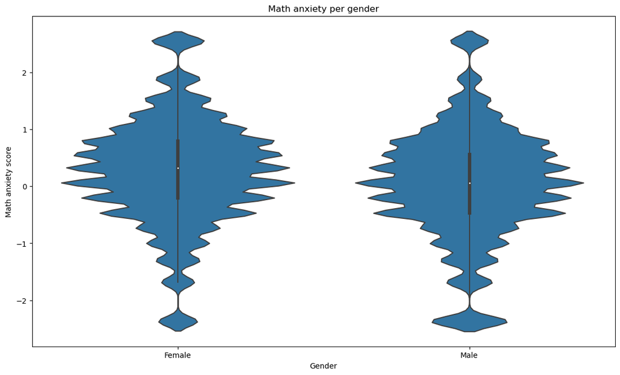

## Relation between math anxiety and math score

The following visualization series shows the strong relation between math anxiety and the math score. The more students disagree with questions the better they score in math.

- Worry That It Will Be Difficult
- Get Very Tense
- Get Very Nervous
- Feel Helpless
- Worry About Getting Poor Grades

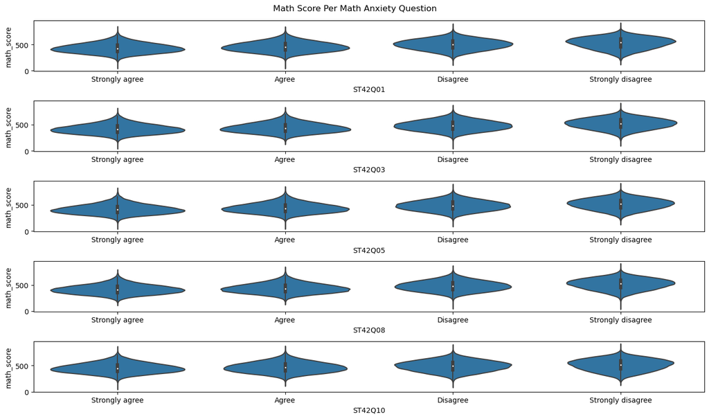

## Relation between math anxiety and math score per gender

This visualization shows the answers to the question `Worry That It Will Be Difficult` in relation to the math score. In the visualization one can see the more students disagree with the survey question they score higher in math. There is also a difference between gender. Male students score higher than female students for each answer. The only exception is for `Strongly disagree` where female students have a higher math score than the male students.

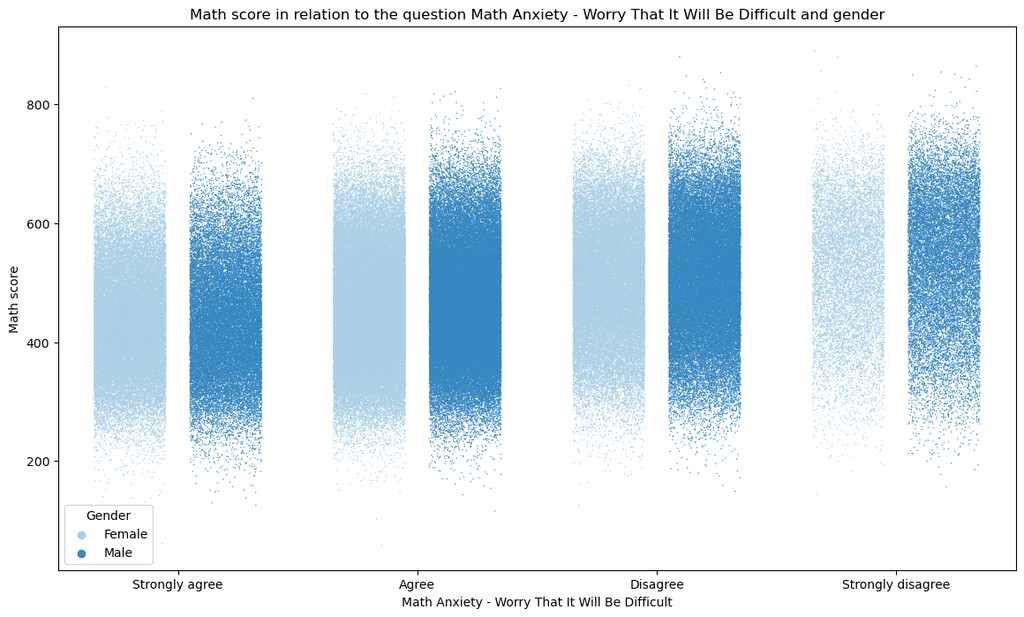